# Assignment 5: VC-Dimension

This material, no matter whether in printed or electronic form, may be used for personal and non-commercial educational use only. Any reproduction of this material, no matter whether as a whole or in parts, no matter whether in printed or in electronic form, requires explicit prior acceptance of the authors.

## Task 1: VC-dimension of subsets of the real line

In this task, you are asked to compute the VC-dimension of certain hypothesis classes on the real line $\mathbb{R}$. No completely rigorous proofs are necessary, a rough verbal description is perfectly fine; it also might be a good idea to assist your claims with graphical arguments, i.e. by uploading pictures of your sketches to your notebooks (or producing them in Latex or Python). By doing so, argue that:

- The VC-dimension of the hypothesis class of (indicators of) intervals is $2$.
- The VC-dimension of the hypothesis class of (indicators of) unions of $k$ intervals is $2k$.

### Calculation (10+15 Points):

- If we want to find the VC-dimension of the hypothesis class of $2$ interval, we can crorrectly lable a point set from following example points : $$\oplus|\ominus|\oplus|\ominus$$ It can be shown that label format is consistent with four points in different structures. In other words, each interval can shatter at least one pair of consecutive points. However, for more than four points on a real line can not be shattered using only $2$ intervals as shown for examle five distinct points: $$\oplus|\ominus|\oplus|\ominus\oplus$$

  Therefore, the VC-dimension of hyphothesis class of $2$ interval is $4$
- In a general case, when there are $k$ interval, similarly, each interval is enough to shatter at least one pair of consecutive points. Therefore, $k$ interaval can shatter any $2k$ distinct points on the real line. The simple schematic can be shown as: $$\oplus|\ominus|\oplus|\ominus|\cdots|\oplus|\ominus|\oplus|\ominus$$ where $2k$ points are shattered with considered $k$ interval which is shown with two vertical line $(|\cdot|)$. In contrast, by assuming $2k+1$ points $x_i$ where $i\in[1,2k+1]$ and $x_i=(-1)^{i}$ the label points can be positive or negetive as follow:$$\ominus|\oplus|\ominus|\oplus|\ominus|\cdots|\oplus|\ominus|\oplus|\ominus$$ where it include $k+1$ negative labeled points that required $2k+1$ interval to shatter this set. Otherwise, with lower number of intervals, one of them include two consecutive points with different labels.

  $\implies$ Consequently, (at most) $2k$ points with mentioned sequence can be shattered with $k$ intervals and the VC-dimension of the union of $k$ intevals in $2k$.

## Task 2: VC-dimension of subsets of the plane

In this task, we are now investigating the situation on the plane $\mathbb{R}^2$ for certain hypothesis families. Again, no completely rigorous proofs are necessary, a rough verbal description is perfectly fine; it also might be a good idea to assist your claims with graphical arguments, i.e. by uploading pictures of your sketches to your notebooks (or producing them in Latex or Python). By doing so, argue that:

- The VC-dimension of the hypothesis class of (indicators of) axis aligned rectangles is $4$.
- The VC-dimension of the hypothesis class of (indicators of) axis aligned squares is $3$.
- The VC-dimension of the hypothesis class of (indicators of) general triangles is greater or equal than $7$. (It is in fact $=7$, but this is harder to prove and requires some more advanced geometric arguments.) (Hint: consider $7$ points lying on a circle and distinguish the cases where there are more positive than negative labels vs. the other way round.)

### Calculation (15+15+15 Points):

- VC-dimension of the hyphotesis class of axis aligned rectangular is $4$. If we consider a set of four points that shatters, as shown

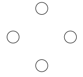

  there is an axsis aligned retangular that contains a subset of the points but no others. Thus, the VC-dimension is at leat four. Consider a set of five point in on the plane $\mathbb{R}^2$. We can not place five points in two dimensions anywhere such a rectangular can separate the positive and negative examples for all possible labeling. Consider a rectangular that contains the points with maximum and minimum of x-coordinate and maximum and minimum of y-coordinate. There are at most four such points. if there is five points, there is at least one point in rectangular with wrong labeling. Therefore, one points can not be consistent with labeling of any axis-aligned rectangule. This means that there is no shattered set of size 5.
- The VC-dimension of the hypothesis class of axis aligned squares is $3$. As shown three points that are the vertices of an equilateral triangle.

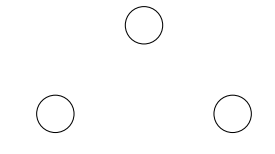

  An axis aligned square can shtter these 3 points. Now, consider a square that 4 poitns lie within or on the square. By moving this square along one axis, the label of individual points can be changed. We should assume four points form a convex shape othrewise at least one point lies in the convex hull of these points and correct labeling can not be achieved. In this case, the bounding square must touch at least three points out of four. Then, since each diagonal of the square has two vertices, at least one of the these diogonal have both points on the size of the square. Then, if both points on the diagonals are labeled the same, remain two other poitns that can not attain the correct labeling. Therefore, the VC dimension of axis aligned square is 3.
- The VC-dimension of the hypothesis class of (indicators of) general triangles is greater or equal than 7. All possible labeling of the seven points which aligned on a circle can be separated using the triangles/ The points are shown as

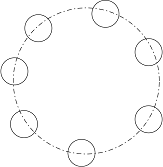

These seven points on that can be labeled in any way because in any cases, there are at least 3 negative points of whole blocks. Therefore, the edges of triangle can be used to cut off this blocks. However, there is not a set of 8 points which can be shattered. if one of the points is inside the convex hull of the rest, it is not possible to label this point opposite to the rest remaining points, otherwise, the order of labeling is not attainable, the figure below is show an example situation with cross (negative) and positive points

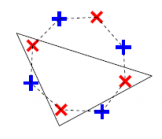

These tasks should convince you about the following observations: first, simple figures, which at first sight look very similar geometrically, might lead to different properties concerning their abilities of separating data(like squares, rectangles and triangles). Secondly, if the complexity of the separating class gets higher, then this usually also leads to better separation properties as indicated in the first example. Even the number of parameters that characterize the hypothesis class is not an indicator for it's VC-dimension: in the lecture even an example of a one-parameter family with infinite VC-dimension was mentioned.

## Task 3: Programming example with VC-Dimension

In this task, a programming example should further strenghen your intuition about how model complexity affects the performance of a classifier and how this is related to its VC-dimension.

### Task:

First of all we want to create binary labelled data within the unit circle. Therefore implement a function "create_data" that depends on a parameter $k\in \mathbb{N} \geq 2$, which returns $k$-labeled data drawn uniformly from the unit circle with binary labels contained in $\{-1,1\}$, such that the points in one half of the circle should be labeled with $1$, and points in the other half by $-1$. We provide the code for the first two data points, which we label with $+1$ and $-1$, respectively. (The reason for this is that we need to guarantee at least two different labels for the upcoming tasks. Keep in mind that we label them randomly, no matter where they lie in the plane. For creating further points you should proceed differently!) You should now finish the code according to the description above. Hint: to understand the procedure for the first two points, recall that points within the unit circle can be written as $\left( r \cos\varphi, r \sin\varphi\right)$, where $0\le r \le 1$ and $0 \le \varphi \le 2 \pi$.

Next, we want to implement a linear support-vector classifier (SVC) that separates the data "as accurately as possible", using a separating hyperplane (in our case: a straight line, as we are considering the situation in the plane). What we want to achieve in the end is that the separating line's distance from the data should be as large as possible (indicated by a large so called "margin"), so that also test data can be classified as accurately as possible. As this usually isn't possible in general situations (e.g. when a lot of randomness is present in the data), certain variables, that don't exactly fit in this framework have to be "punished" using so called slack-variables. It might e.g. be allowed for a certain amount of points to lie inside the margin or lie on the wrong side of the borders. This procedure in many situations can improve the generalization performance of the classifier. In any case, we won't go into the details here, and just mention that the amount of this "punishment" is encoded in the hyperparameter $C$ for the SVC. For further information consult e.g. the lecture notes for the supervised learning course.

We provide the code for the implementation of the SVC using the sklearn-toolkit. Also a function, that outputs the margin for a SVM classifier is provided. For more details, consult https://scikit-learn.org/stable/modules/generated/sklearn.svm.SVC.html#sklearn.svm.SVC. Your task is now the following:

### Task:

Write a function "compute_svm" that again depends on a parameter $k\in \mathbb{N} \geq 10$, and that computes linear SVCs for up to $k$ data points created via the "create_data" function using a for-loop. For each number of data points the corresponding margin should be printed and stored in a list. So in the end for each $10 \le j \le k$ a different SVC for $j$ data distributed according to the procedure from the previous question should be computed and the corresponding margin should be stored. The output of the function should be the list containing the margins. Run compute_svm(1000) and store the outputted list. The code for computing the SVC and its margin for a fixed number of data is provided.

### Task:

Now we want to relate the behavior of the margin to theoretical results concerning the VC-dimension: It holds that for data which lie in a ball of radius $R$, the VC-dimension $d_{VC}$ of a linear support-vector classifier with margin $\gamma$ is bounded by $d_{VC} \le \frac{R^2}{\gamma^2}$ (cf. page 63 in the lecture notes). Using this fact, visualize the dependence of the margin and the VC dimension on the number of data points in two separate plots, using the previously produced list of margin values. Remember that all our data are contained in the unit circle.

```python
# Some code that should help you. Nothing to do here

import sklearn as sk
import numpy as np
import matplotlib.pyplot as plt
from sklearn import svm
# Create empty list that should store feature values.
x=[]
# Create empty list that should store labels.
y=[]
# Randomly create one point within unit circle with label y=1, store features and labels in the corresponding lists.
length_1 = np.random.uniform(0, 1)
angle_1 = np.pi * np.random.uniform(0, 2)
x.append([np.sqrt(length_1) * np.cos(angle_1), np.sqrt(length_1) * np.sin(angle_1)])
y.append(1)
# Randomly create another point within unit circle with label y=-1, store features and labels it in the corresponding lists.
length_2 = np.random.uniform(0, 1)
angle_2 = np.pi * np.random.uniform(0, 2)
x.append([np.sqrt(length_2) * np.cos(angle_2), np.sqrt(length_2) * np.sin(angle_2)])
y.append(-1)
print(x,y)
# Code for linear SVC containing only the previously created points as data, also outputs corresponding margin.
clf = svm.SVC(kernel='linear',C=10)
clf.fit(x,y)
margin=2/np.linalg.norm(clf.coef_)
print("Margin of SVM =",margin)
```

```
[[0.5942383249061847, 0.7196041804009057], [0.38047020518251207, 0.7084164793448057]] [1, -1]
Margin of SVM = 0.9343145238380004
```

### Code (10+10+10 Points):

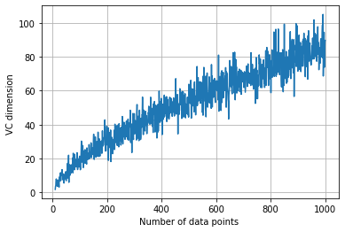

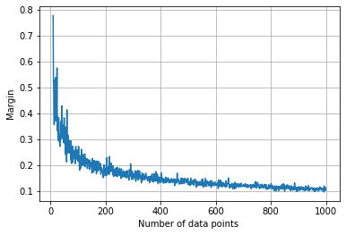

```python
###################################
# Begin your code
def create_data(k):
    r = np.random.uniform(0, 1, size=k)
    phi = np.pi * np.random.uniform(0, 2, size=k)
    a = np.array([np.sqrt(r) * np.cos(phi)])
    b = np.array([np.sqrt(r) * np.sin(phi)])
    X = np.concatenate((a.T, b.T),axis=1)
    y = [+1 if elem>0 else -1 for elem in a.ravel() ]

    # plot the data with colored label
    if False:
        color=['red' if elem2==+1 else 'blue' for elem2 in y ] #  ['red' if elem>0 else 'blue'  for elem in a.ravel() ]
        fig = plt.figure()
        ax = fig.add_subplot()
        circ = plt.Circle((0, 0), radius=1, edgecolor='b', facecolor='None')
        ax.add_patch(circ)
        ax.scatter(X[:,0], X[:,1], c=color,label='the data')
        ax.axis('equal')
        plt.show()

    return X,y

def compute_svm(k):
    X_list = []
    y_list = []
    margin_list = []
    for j in range(10,k+1):
        X,y = create_data(j)
        X_list.append(X)
        y_list.append(y)
        clf = svm.SVC(kernel='linear',C=10)
        clf.fit(X,y)
        margin=2/np.linalg.norm(clf.coef_)
        margin_list.append(margin)

    # print("Margins of SVM =",margin_list)

    return margin_list

k = 1000
n_points = np.arange(10,k+1)
gamma = np.asarray(compute_svm(k))
R = 1
dvc = (R**2)/(gamma**2)
plt.figure()
plt.plot(n_points, dvc)
plt.xlabel('Number of data points ')
plt.ylabel('VC dimension ')
plt.grid()
plt.figure()
plt.plot(n_points, gamma)
plt.xlabel('Number of data points ')
plt.ylabel('Margin')
plt.grid()


# End your code
###################################
```

It should be clearly visible from the plot, that, up to small fluctuations, the value of the margin decreases for a larger number of data points. This should come as no surprise, since the model gets increasingly complex for a larger number of data, and therefore a clearer separation is harder, which is indicated by smaller margins. Also the increase of the VC-dimension is reasonable, since VC-dimension provides an indicator for model complexity and it indeed seems to be a reasonable concept that can provide a theoretical basis for measuring the quality of widle applied classifier algorithms.